# Synthetic Control Methods

Author

Affiliation

Jonathan Elkobi

Yale University, Department of Political Science

Published

July 16, 2026

Abstract

Synthetic control methods estimate what would have happened to a treated unit without treatment by constructing a weighted comparison from untreated units. This guide develops the method around a single running example, California’s Proposition 99, and uses simulated panels with known answers to show what good and bad designs actually look like. It covers the design logic, diagnostics, a reproducible Synth workflow, generalized synthetic control in fect, augmented synthetic controls, and bounded or proportion outcomes.

Keywords

synthetic control, causal inference, program evaluation, counterfactuals, panel data, policy evaluation

**Setup: R packages and Stata/Python engines**

```r
# Reproducibility: pacman installs any missing CRAN packages, then loads them all.
if (!requireNamespace("pacman", quietly = TRUE)) install.packages("pacman")
pacman::p_load(
  Synth, fect, tidysynth,             # synthetic control estimators (CRAN)
  dplyr, tidyr, ggplot2,              # data wrangling and plotting
  Statamarkdown,                      # Stata engine for knitr
  reticulate                          # Python engine for knitr
)
# augsynth is GitHub-only. Install it ONCE outside the render (see the
# Reproducibility appendix); we only attach it here, with no network call.
if (!requireNamespace("augsynth", quietly = TRUE)) {
  stop("Package 'augsynth' is not installed. It is not on CRAN; install it once with\n",
       '  pacman::p_load_gh("ebenmichael/augsynth")\n',
       '  # or  remotes::install_github("ebenmichael/augsynth")\n',
       "See the Reproducibility appendix at the end of this document.")
}
library(augsynth)

# Python engine: this guide ships parallel R / Python / Stata code in every
# tabset (see the "Cross-language translation" appendix). A global
# RETICULATE_PYTHON in ~/.Rprofile would otherwise override use_virtualenv(), so
# clear it and bind this guide's own ./.venv (which has pysyncon, etc.).
Sys.unsetenv("RETICULATE_PYTHON")
reticulate::use_virtualenv(file.path(getwd(), ".venv"), required = TRUE)

# The Stata tabs write intermediate .dta handoffs; keep them out of the project
# root by pointing them at a scratch folder inside synthetic-control_files/.
dir.create("synthetic-control_files/stata", showWarnings = FALSE, recursive = TRUE)
# Stata graphs are exported to sc_figs/ and included as images (Statamarkdown
# does not auto-embed them). `graph export` errors with r(603) if the directory
# does not already exist, and sc_figs/ is gitignored, so create it here.
dir.create("sc_figs", showWarnings = FALSE, recursive = TRUE)

theme_set(theme_minimal(base_size = 12))
PAL <- c(treated = "#B22222", synth = "#1F4E79", donor = "grey70")
```

**Setup: Python imports (shared by every Python tab)**

```python
# Imported once; reticulate keeps a single Python session for the whole document,
# so every Python tab below can use np / pd / plt / pysyncon and any object a
# prior Python tab defined (fit_good, pl_keep, ...).
import numpy as np
import pandas as pd
import matplotlib.pyplot as plt
from pysyncon import Dataprep, Synth, AugSynth

plt.rcParams["figure.figsize"] = (8, 4.5)
PAL = {"treated": "#B22222", "synth": "#1F4E79", "donor": "0.7"}

# Simulation constants, mirroring the R "Simulation design" blocks.
J, T0, TT = 25, 20, 35
```

# Introduction

In 1988, California passed Proposition 99. The state raised its cigarette excise tax by 25 cents a pack and funded an anti-smoking campaign with the revenue. Cigarette sales in California then fell.

That last sentence is not yet a finding. Sales were *already* falling in California before 1988, and they were falling across the country. The question that matters is counterfactual: **how many packs would Californians have bought if Proposition 99 had never passed?** That quantity is never observed, and everything hard about this design lives in estimating it.

## Why the Obvious Comparisons Fail

The natural instinct is to find a comparison state. The problem is that the treatment is *idiosyncratic*: it happened to exactly one unit, and that unit is unlike every other one.

- **Pick one similar state.** New York? It is more urban, has different tobacco politics, and its own tax history. Nevada? Different demographics entirely, and a tourism economy that moves cigarette sales for reasons unrelated to health policy. There is no second California sitting in the data, and any single choice is one referee question away from collapsing.
- **Average all the other states.** The average of 38 states is a perfectly well-defined object, and it is not California either. California smoked less than the national average and was on a steeper downward path well before 1988. Compare California to the national average and you will “find” an effect that started years before the policy did.

This is the recurring situation for aggregate interventions. The treatment is clean and unambiguous. The counterfactual is a mess, because every unit is unique in its own way.

## The Synthetic Control Idea

Synthetic control methods resolve this by refusing to pick a comparison and refusing to weight everyone equally. Instead, they *build* one.

The method searches for a set of weights across the untreated states and forms a weighted average, a “synthetic California,” subject to one demand: **the weighted average must reproduce California’s own pre-1988 path.** Not California’s level in one year, and not its average, but its trajectory over the years leading up to the policy.

The logic is a matching argument moved from units to time. If a particular blend of Utah, Nevada, Montana, Colorado, and Connecticut tracked California’s cigarette sales year after year through the 1970s and 1980s, when neither California nor those states had Proposition 99, then that blend is a credible stand-in for what California was going to do next. After 1988, the blend keeps running as a no-treatment California. The two paths then differ by one thing that was not true before: California has the policy and the blend does not.

**Synthetic Control in One Sentence**

Build a comparison unit that reproduces the treated unit’s path *before* treatment, then ask whether the two paths separate *after* treatment.

Two features of this are worth naming immediately, because they drive everything that follows.

First, **the pre-treatment fit is where the identifying argument becomes visible, not a preliminary step.** In a regression you assume the comparison is valid. Here you display it. A reader can look at the pre-1988 fit and judge for themselves whether the counterfactual earned the right to speak about 1989. A good fit is necessary but not sufficient, a point we sharpen once we meet an estimator flexible enough to fit any past.

Second, **the method can visibly fail.** If no weighted blend of donors reproduces the treated unit’s pre-treatment path, you can see it in the figure. That is not a software problem; it is the design telling you that your data do not contain a plausible untreated version of the treated unit. Later in this guide we simulate exactly that case and watch the estimate go wrong in a specific, diagnosable way.

## Is SCM the Right Design?

| Use SCM when… | Pause or use something else when… |
| --- | --- |
| One unit, or a small number of units, receives a well-defined intervention. | Treatment is vague, anticipated, reversible, or badly timed. |
| The unit is aggregate: a country, state, city, school district, firm, project area, or region. | Your data are primarily individual-level and rich in observed confounders. |
| You have a donor pool of untreated units observed before and after treatment. | Likely donors are affected by spillovers, related policies, or the treatment itself. |
| No single comparison unit is credible. | The treated unit is unlike every plausible donor before treatment. |
| The pre-treatment record is long enough to assess fit. | You have three pre-treatment periods and a hope. |

SCM is not magic. It is a way to learn whether your data contain a plausible untreated version of the treated unit. Sometimes the answer is no, and learning that early is a useful result.

## Where SCM Gets Used

The same structure recurs across fields: one aggregate unit gets something, the counterfactual is contested, and the donor pool is the whole argument.

| Domain | Treated unit | Outcome | Donor pool | What makes the counterfactual hard |
| --- | --- | --- | --- | --- |
| **Tobacco policy** | California, 1988 | Cigarette packs sold per capita | Other US states without comparable programs | California was already on a distinctive downward trend (Abadie, Diamond, and Hainmueller 2010) |
| **Political conflict** | Basque Country, from the 1970s | Real GDP per capita | Other Spanish regions | The region was economically atypical before the conflict (Abadie and Gardeazabal 2003) |
| **Macro shocks** | West Germany, 1990 | GDP per capita | Other industrialized economies | No country is “Germany without reunification” (Abadie, Diamond, and Hainmueller 2015) |
| **Carbon offsets** | Forest project area | Forest loss or deforestation share | Comparable non-project forest areas | The credited baseline *is* the estimand, and nearby areas may absorb displaced logging (West et al. 2023) |
| **Economic shocks** | The UK after the 2016 Brexit referendum | Real output | Other advanced economies | Markets and firms respond to the expected policy before it takes effect (Born et al. 2019) |

# Theory

## Potential Outcomes Setup

Let units be indexed by $i = 1, \ldots, J + 1$. Unit $1$ is treated; units $2$ through $J + 1$ are untreated donors. Time runs from $t = 1, \ldots, T$, and treatment begins after $T_0$. The periods $1,\ldots,T_0$ are pre-treatment.

Each unit has two potential outcomes:

- $Y_{it}(1)$ is the outcome under treatment.
- $Y_{it}(0)$ is the outcome without treatment.

After treatment begins, we observe $Y_{1t}(1)$ for the treated unit but never observe $Y_{1t}(0)$. The period-specific treatment effect is therefore:

$$\alpha_{1t} = Y_{1t}(1) - Y_{1t}(0), \quad t > T_0.$$

SCM estimates the missing untreated outcome with a weighted average of donor outcomes:

$$\widehat{Y}_{1t}(0) = \sum_{j=2}^{J+1} w_jY_{jt},$$

so the estimated gap is:

$$\widehat{\alpha}_{1t} =
Y_{1t} - \sum_{j=2}^{J+1} w_jY_{jt}, \quad t > T_0.$$

The gap plot is the figure everyone wants to see. A post-treatment gap is persuasive only when the pre-treatment fit makes it believable.

## How Classical SCM Chooses a Counterfactual

Let $X_1$ be a vector of pre-treatment predictors for the treated unit, and let $X_0$ contain the same predictors for the $J$ donor units. Classical SCM chooses donor weights $W = (w_2, \ldots, w_{J+1})$ to minimize pre-treatment imbalance:

$$\widehat{W}(V) = \arg\min_W (X_1 - X_0W)^\top V(X_1 - X_0W),$$

subject to:

$$w_j \geq 0 \quad \text{and} \quad \sum_{j=2}^{J+1}w_j = 1.$$

$V$ assigns importance to different predictors. The donor weights $W$ tell us which units build the synthetic control. $V$ decides what counts as a good match; $W$ is the match.

The nonnegative, sum-to-one restrictions matter more than they look. They make the synthetic control a **convex combination** of real donors, which means the counterfactual can never leave the range spanned by units you actually observed. No extrapolation into territory no donor occupies. We return to this when outcomes are bounded, where the restriction stops being a philosophical preference and starts preventing impossible numbers.

That buys transparency, not automatic credibility. If synthetic California is mostly Utah and Nevada, a reader can decide whether that is substantively sensible.

**A Predictor Set Can Defeat Itself**

Feeding the optimizer the full pre-treatment outcome path alongside other covariates is a common instinct: more pre-treatment fit should be better. It can backfire. When the outcome path dominates, the $V$-optimization can drive the importance weights on the other covariates toward zero, so the “balance on predictors” diagnostic ends up checking a predictor set the optimizer never actually used (Kaul et al. 2022). A closely related failure mode is cherry-picking the predictor set or donor pool after seeing which choices produce an appealing gap (Ferman, Pinto, and Possebom 2020). Fix the predictor set and donor pool before looking at post-treatment results.

## Identification: What You Must Defend

The identifying claim is simple to state and hard to earn: a donor combination that mimics the treated unit before treatment is a good approximation to what the treated unit would have done after treatment without treatment.

Under the latent-factor view, untreated outcomes reflect common time shocks, observed predictors, and unobserved factors with unit-specific loadings. Matching a long pre-treatment path can also match the treated unit’s exposure to those latent factors (Abadie 2021; Xu 2017). It is a helpful intuition, not a permission slip: the argument requires a pre-treatment window that is long relative to the number of latent factors, and a fit that is close to exact, not merely close-looking on a plot. As fit quality degrades, so does the bound on the resulting bias (Abadie 2021).

Before interpreting an estimate, defend these conditions:

| Design condition | Practical question |
| --- | --- |
| **Clear treatment timing** | When did behavior, policy, or anticipation actually begin? |
| **Clean donor pool** | Could any donor be affected by spillovers, related policies, displacement, or anticipation? |
| **Plausible support** | Can donors reproduce the treated unit before treatment without heroic extrapolation? |
| **Stable measurement** | Is the outcome measured consistently across units and over time? |
| **Informative pre-period** | Is there enough pre-treatment history to see persistent fit, not just accidental overlap? |

## Diagnostics Are the Method

SCM lives or dies by diagnostics. The estimate is not one number; it is a design with receipts.

| Diagnostic | What it checks | What a bad result means |
| --- | --- | --- |
| Pre-treatment RMSPE | Average mismatch before treatment | The synthetic control does not track the treated unit well enough. |
| Path plot | Treated and synthetic outcomes over time | Pre-period divergence undermines the post-period story. |
| Gap plot | Treated minus synthetic outcome | A post-treatment gap is only meaningful relative to pre-period gaps. |
| Predictor balance | Whether matching improves relevant predictors | Balance helps, but it cannot rescue a bad outcome path. |
| Donor weights | What the synthetic unit is made of | Large weights identify donors that need substantive scrutiny. |
| Placebo tests | Whether the treated gap is unusual among fake-treated donors | The observed pattern may be ordinary design noise. |
| Leave-one-out checks | Dependence on high-weight donors | The conclusion may rest on one donor. |
| Donor-pool sensitivity | Dependence on defensible exclusion rules | The result may be an artifact of one convenient pool. |

### RMSPE Is a Diagnostic, Not a Universal Threshold

The pre-treatment root mean squared prediction error is:

$$RMSPE_{pre} =
\sqrt{\frac{1}{T_0}\sum_{t=1}^{T_0}
\left(Y_{1t} - \widehat{Y}_{1t}(0)\right)^2}.$$

Smaller is better. There is no sacred cutoff that converts a weak design into a strong one. Judge the error on the outcome’s scale, compare it with placebo fits, and show the path plot.

### Placebos and Permutation Logic

For a placebo test, temporarily label each eligible donor as treated at the original treatment date, build its synthetic control, and compare its post-treatment gap with the treated unit’s gap. The point is not to manufacture a familiar regression p-value. It is to ask whether the treated unit looks unusual relative to units that received fake treatment.

For a chosen test statistic $S$, a simple randomization-style summary is:

$$p = \frac{1 + \sum_{j \in \mathcal{D}} I\left\{S_j \geq S_{treated}\right\}}
{1 + |\mathcal{D}|},$$

where $\mathcal{D}$ includes placebo units with acceptable pre-treatment fit. State the statistic, the fit-screening rule, and whether the comparison is one- or two-sided.

Placebo permutation is not the only principled option, and it depends on having a donor pool large enough to support comparison. Chernozhukov, Wüthrich, and Zhu develop an exact conformal-inference procedure for synthetic control settings that does not rely on a large cross-section of placebo units (Chernozhukov, Wüthrich, and Zhu 2021). Cattaneo, Feng, and Titiunik develop prediction intervals for the synthetic control estimate itself, implemented in the `scpi` package (Cattaneo, Feng, and Titiunik 2021).

# Seeing It Work and Fail

Everything above is a claim about what diagnostics buy you. This section tests those claims on simulated data, where we know the true answer and can check whether the diagnostics actually catch a bad design.

We generate panels from a factor model, the data-generating process the identification argument assumes:

$$Y_{it}(0) = \mu + \alpha_i + \lambda_i' f_t + \varepsilon_{it},$$

with two latent factors $f_t$ and unit-specific loadings $\lambda_i$. Two scenarios differ in exactly one respect:

- **Good support:** the treated unit’s factor loadings sit *inside* the range spanned by the donors, so a convex combination can reproduce them.
- **Poor support:** the treated unit’s loadings sit far *outside* the donor range, so no convex combination can.

In both cases we inject the same known treatment effect: a ramp that grows by $-1.2$ units per period after $T_0$, averaging $-9.6$ over the post-treatment window. The design question is whether the diagnostics tell us when to trust the estimate.

The panels are generated once in R and written to `synthetic-control_files/data/`, so the R, Python, and Stata analyses below all read the *same* numbers. The generator is R-only (it depends on R’s random-number stream); expand the box if you want to see exactly how the data were built.

**Simulation design (click to expand)**

```r
set.seed(20260720)

J <- 25    # number of donors
TT <- 35   # total periods
T0 <- 20   # last pre-treatment period
EFF <- -1.2

f1 <- scale(cumsum(rnorm(TT, 0, 1)))[, 1]        # a stochastic trend
f2 <- sin(seq(0, 3 * pi, length.out = TT))       # a slower cycle
tau <- c(rep(0, T0), EFF * seq_len(TT - T0))     # the true effect path

make_panel <- function(lam_treated, seed = 20260720) {
  set.seed(seed)
  lam <- cbind(runif(J, 0, 1), runif(J, 0, 1))   # donor loadings in the unit square
  alpha <- rnorm(J, 0, 3)
  Y <- matrix(NA_real_, nrow = J + 1, ncol = TT)
  for (i in 1:J) {
    Y[i + 1, ] <- 120 + alpha[i] +
      8 * lam[i, 1] * f1 + 8 * lam[i, 2] * f2 + rnorm(TT, 0, 1)
  }
  Y[1, ] <- 120 + 8 * lam_treated[1] * f1 + 8 * lam_treated[2] * f2 +
    rnorm(TT, 0, 1) + tau
  data.frame(
    id   = rep(1:(J + 1), each = TT),
    name = rep(paste0("u", 1:(J + 1)), each = TT),
    time = rep(1:TT, times = J + 1),
    Y    = as.vector(t(Y))
  )
}

# Freeze the two scenarios and the ground truth to disk for the other languages.
dir_sim <- "synthetic-control_files/data"
write.csv(make_panel(c(0.5, 0.5)), file.path(dir_sim, "sim_good.csv"), row.names = FALSE)
write.csv(make_panel(c(2.6, 2.6)), file.path(dir_sim, "sim_bad.csv"),  row.names = FALSE)
write.csv(data.frame(time = 1:TT, f1 = f1, f2 = f2, tau = tau),
          file.path(dir_sim, "sim_truth.csv"), row.names = FALSE)

cat("True mean post-treatment effect:", mean(tau[(T0 + 1):TT]))
```

```
True mean post-treatment effect: -9.6
```

One helper does all the fitting. It matches on every pre-treatment outcome, which is the standard outcome-only synthetic control, and returns the pieces every diagnostic needs.

**R**

```r
fit_scm <- function(df, treated, donors, T0, TT) {
  sp <- lapply(1:T0, function(t) list("Y", t, "mean"))
  prep <- dataprep(
    foo = df, dependent = "Y",
    unit.variable = "id", unit.names.variable = "name", time.variable = "time",
    special.predictors = sp,
    treatment.identifier = treated, controls.identifier = donors,
    time.predictors.prior = 1:T0, time.optimize.ssr = 1:T0, time.plot = 1:TT
  )
  invisible(capture.output(res <- synth(prep)))
  synth_path <- as.vector(prep$Y0plot %*% res$solution.w)
  observed <- as.vector(prep$Y1plot)
  gap <- observed - synth_path
  list(
    observed = observed, synth = synth_path, gap = gap,
    w = setNames(as.vector(res$solution.w), colnames(prep$Y0plot)),
    rmspe_pre = sqrt(mean(gap[1:T0]^2)),
    att_post  = mean(gap[(T0 + 1):TT])
  )
}
```

**Python**

```python
import pandas as pd
import numpy as np
from pysyncon import Dataprep, Synth

J, T0, TT = 25, 20, 35   # same constants as the simulation design

def fit_scm(df, treated, donors, T0, TT):
    """Outcome-only synthetic control, matching every pre-period outcome."""
    dp = Dataprep(
        foo=df, dependent="Y", unit_variable="name", time_variable="time",
        treatment_identifier=treated, controls_identifier=donors,
        predictors=[], predictors_op="mean",
        special_predictors=[("Y", [t], "mean") for t in range(1, T0 + 1)],
        time_predictors_prior=range(1, T0 + 1), time_optimize_ssr=range(1, T0 + 1),
    )
    s = Synth()
    s.fit(dp)
    wide = df.pivot(index="time", columns="name", values="Y").sort_index()
    synth = wide[donors].values @ np.asarray(s.W)
    obs = wide[treated].values
    gap = obs - synth
    return dict(observed=obs, synth=synth, gap=gap,
                w=pd.Series(np.asarray(s.W), index=donors),
                rmspe_pre=float(np.sqrt(np.mean(gap[:T0] ** 2))),
                att_post=float(np.mean(gap[T0:])))
```

**Stata**

```stata
* Stata runs `synth` per fit. Because each code block here is a fresh Stata
* session, the analyses below call `synth` inline rather than sharing a helper;
* the reusable shape of that call, for an outcome-only fit on a tsset panel
* with outcome Y over periods 1..T0, is:
*
*   local pre ""
*   forvalues t = 1/`T0' {
*       local pre "`pre' Y(`t')"
*   }
*   synth Y `pre', trunit(<id>) trperiod(`=`T0'+1') ///
*         mspeperiod(1(1)`T0') resultsperiod(1(1)`TT') keep(<file>, replace)
display "See the analysis blocks below for the inline synth calls."
```

```
See the analysis blocks below for the inline synth calls.
```

## Two Fits, One Truth

**R**

```r
panel_good <- read.csv("synthetic-control_files/data/sim_good.csv")  # inside the hull
panel_bad  <- read.csv("synthetic-control_files/data/sim_bad.csv")   # far outside it

fit_good <- fit_scm(panel_good, 1, 2:(J + 1), T0, TT)
fit_bad  <- fit_scm(panel_bad,  1, 2:(J + 1), T0, TT)

data.frame(
  Scenario        = c("Good support", "Poor support"),
  `Pre-RMSPE`     = round(c(fit_good$rmspe_pre, fit_bad$rmspe_pre), 2),
  `Estimated ATT` = round(c(fit_good$att_post, fit_bad$att_post), 2),
  `True ATT`      = round(mean(tau[(T0 + 1):TT]), 2),
  check.names = FALSE
)
```

```
      Scenario Pre-RMSPE Estimated ATT True ATT
1 Good support      0.67         -9.73     -9.6
2 Poor support     10.97         -1.48     -9.6
```

**Python**

```python
panel_good = pd.read_csv("synthetic-control_files/data/sim_good.csv")
panel_bad  = pd.read_csv("synthetic-control_files/data/sim_bad.csv")
donors = [f"u{i}" for i in range(2, J + 2)]

fit_good = fit_scm(panel_good, "u1", donors, T0, TT)
fit_bad  = fit_scm(panel_bad,  "u1", donors, T0, TT)

truth = pd.read_csv("synthetic-control_files/data/sim_truth.csv")
true_att = truth.loc[truth.time > T0, "tau"].mean()

print(pd.DataFrame({
    "Scenario":      ["Good support", "Poor support"],
    "Pre-RMSPE":     [round(fit_good["rmspe_pre"], 2), round(fit_bad["rmspe_pre"], 2)],
    "Estimated ATT": [round(fit_good["att_post"], 2), round(fit_bad["att_post"], 2)],
    "True ATT":      round(true_att, 2),
}).to_string(index=False))
```

```
    Scenario  Pre-RMSPE  Estimated ATT  True ATT
Good support       0.67          -9.73      -9.6
Poor support      11.03          -2.47      -9.6
```

**Stata**

```stata
tempname R
postfile `R' str12 scenario prermspe estatt using "synthetic-control_files/stata/_fitboth", replace
foreach s in good bad {
    import delimited "synthetic-control_files/data/sim_`s'.csv", clear
    tsset id time
    local pre ""
    forvalues t = 1/20 {
        local pre "`pre' y(`t')"
    }
    quietly synth y `pre', trunit(1) trperiod(21) ///
        mspeperiod(1(1)20) resultsperiod(1(1)35) keep("synthetic-control_files/stata/_scm_`s'", replace)
    preserve
    use "synthetic-control_files/stata/_scm_`s'", clear
    gen gap = _Y_treated - _Y_synthetic
    gen gap2 = gap^2 if _time <= 20
    quietly summarize gap2
    scalar pr = sqrt(r(mean))
    quietly summarize gap if _time > 20
    post `R' ("`s'") (pr) (r(mean))
    restore
}
postclose `R'
use "synthetic-control_files/stata/_fitboth", clear
list scenario prermspe estatt, noobs
```

```
  9.     preserve
 10.     use "synthetic-control_files/stata/_scm_`s'", clear
 11.     gen gap = _Y_treated - _Y_synthetic
 12.     gen gap2 = gap^2 if _time <= 20
 13.     quietly summarize gap2
 14.     scalar pr = sqrt(r(mean))
 15.     quietly summarize gap if _time > 20
 16.     post `R' ("`s'") (pr) (r(mean))
 17.     restore
 18. }
(encoding automatically selected: UTF-8)
(4 vars, 910 obs)

Panel variable: id (strongly balanced)
 Time variable: time, 1 to 35
         Delta: 1 unit
(15 missing values generated)
(encoding automatically selected: UTF-8)
(4 vars, 910 obs)

Panel variable: id (strongly balanced)
 Time variable: time, 1 to 35
         Delta: 1 unit
(15 missing values generated)




  +---------------------------------+
  | scenario   prermspe      estatt |
  |---------------------------------|
  |     good   .6693835   -9.730545 |
  |      bad   10.97087   -1.478045 |
  +---------------------------------+

counter | pri_inf  | dual_inf  | pri_obj   | dual_obj  | sigfig | alpha  | nu
----------------------------------------------------------------------------------
      0 | 6.73e+01 | 1.32e-08 | -3.96e+02 | -6.46e+02 |  0.201 | 0.0000 | 1.00e+02
      1 | 3.36e-01 | 6.62e-11 | -3.96e+02 | -8.51e+02 |  0.000 | 0.9950 | 2.07e-05
      2 | 1.68e-03 | 3.31e-13 | -3.96e+02 | -4.05e+02 |  1.633 | 0.9950 | 2.07e-06
```

[output cut: 13 more lines]

[output not shown]

The numbers already tell the story. With good support the estimate lands within a rounding error of the truth. With poor support it is **severely attenuated**: the method recovers roughly a sixth of the true effect, so an analyst would conclude the intervention did almost nothing when in fact it did a great deal. And the pre-treatment RMSPE is roughly sixteen times larger, which is the tell.

**R**

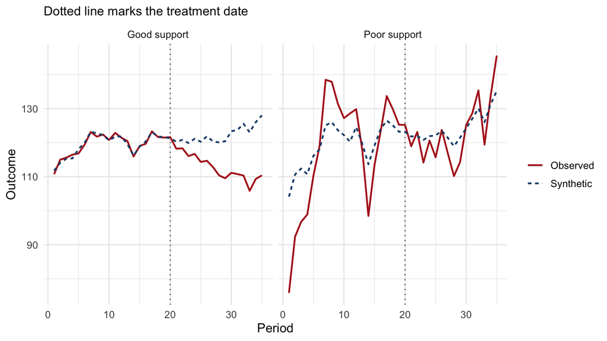

Figure 1: Treated and synthetic paths. When donors cannot span the treated unit (right), the two series never align even before treatment.

```r
path_df <- bind_rows(
  data.frame(time = 1:TT, Observed = fit_good$observed,
             Synthetic = fit_good$synth, panel = "Good support"),
  data.frame(time = 1:TT, Observed = fit_bad$observed,
             Synthetic = fit_bad$synth,  panel = "Poor support")
) |>
  pivot_longer(c(Observed, Synthetic), names_to = "series", values_to = "Y")

ggplot(path_df, aes(time, Y, colour = series, linetype = series)) +
  geom_vline(xintercept = T0, linetype = "dotted", colour = "grey40") +
  geom_line(linewidth = 0.8) +
  facet_wrap(~panel) +
  scale_colour_manual(values = c(Observed = PAL[["treated"]],
                                 Synthetic = PAL[["synth"]])) +
  labs(x = "Period", y = "Outcome", colour = NULL, linetype = NULL,
       subtitle = "Dotted line marks the treatment date")
```

**Python**

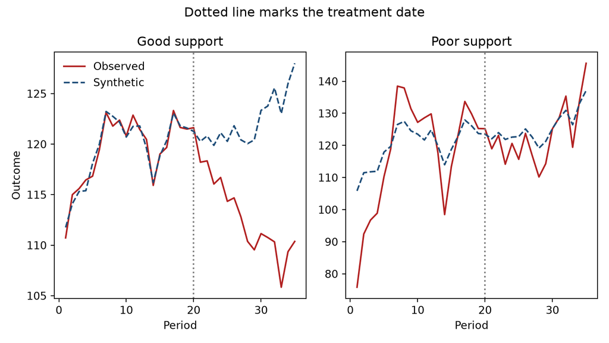

Figure 2

```python
import matplotlib.pyplot as plt

fig, axes = plt.subplots(1, 2, figsize=(8, 4.5))
for ax, fit, title in [(axes[0], fit_good, "Good support"),
                       (axes[1], fit_bad, "Poor support")]:
    t = range(1, TT + 1)
    ax.plot(t, fit["observed"], color="#B22222", label="Observed")
    ax.plot(t, fit["synth"], color="#1F4E79", linestyle="--", label="Synthetic")
    ax.axvline(T0, color="grey", linestyle=":")
    ax.set_title(title)
    ax.set_xlabel("Period")
axes[0].set_ylabel("Outcome")
axes[0].legend(frameon=False)
fig.suptitle("Dotted line marks the treatment date")
plt.tight_layout()
plt.show()
```

**Stata**

```stata
* Uses the fit files saved by the fit-both block (_scm_good, _scm_bad).
use "synthetic-control_files/stata/_scm_good", clear
twoway (line _Y_treated _time, lcolor("178 34 34")) ///
       (line _Y_synthetic _time, lcolor("31 78 121") lpattern(dash)), ///
       xline(20, lpattern(dot)) title("Good support") ///
       legend(order(1 "Observed" 2 "Synthetic")) name(g_good, replace) nodraw
use "synthetic-control_files/stata/_scm_bad", clear
twoway (line _Y_treated _time, lcolor("178 34 34")) ///
       (line _Y_synthetic _time, lcolor("31 78 121") lpattern(dash)), ///
       xline(20, lpattern(dot)) title("Poor support") ///
       legend(off) name(g_bad, replace) nodraw
graph combine g_good g_bad, ycommon
quietly graph export "sc_figs/fig-paths-stata.svg", replace width(1600)
```

[figure not shown]

The left panel is what a usable design looks like: the two lines are indistinguishable before period 20, then separate. The right panel is what failure looks like, and it fails *visibly* and *before* the treatment date. Anyone can see it without knowing the true effect.

**R**

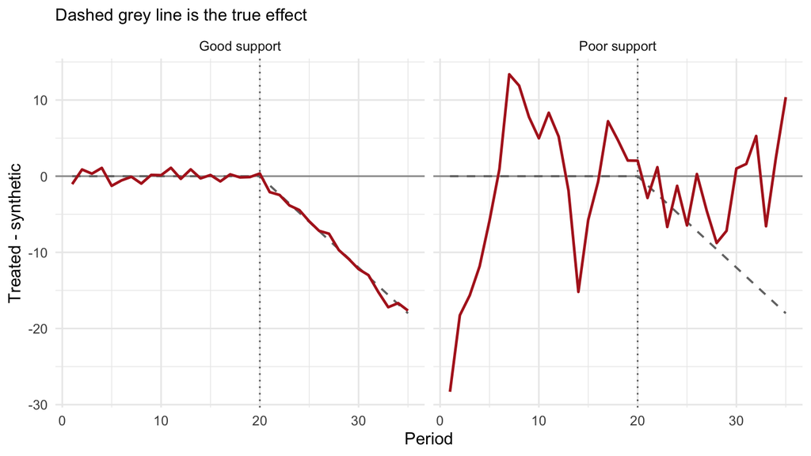

Figure 3: Estimated gaps against the true effect path. Poor pre-treatment support produces a gap that is already large and erratic before treatment.

```r
gap_df <- bind_rows(
  data.frame(time = 1:TT, gap = fit_good$gap, panel = "Good support"),
  data.frame(time = 1:TT, gap = fit_bad$gap,  panel = "Poor support")
)
truth_df <- data.frame(time = 1:TT, gap = tau)

ggplot(gap_df, aes(time, gap)) +
  geom_hline(yintercept = 0, colour = "grey60") +
  geom_vline(xintercept = T0, linetype = "dotted", colour = "grey40") +
  geom_line(data = truth_df, aes(time, gap), colour = "grey45",
            linetype = "dashed", linewidth = 0.7) +
  geom_line(colour = PAL[["treated"]], linewidth = 0.9) +
  facet_wrap(~panel) +
  labs(x = "Period", y = "Treated - synthetic",
       subtitle = "Dashed grey line is the true effect")
```

**Python**

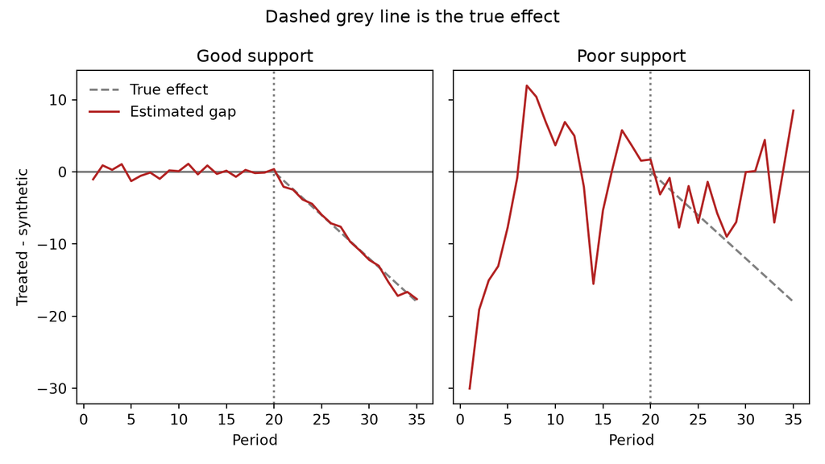

Figure 4

```python
tau = truth["tau"].values
fig, axes = plt.subplots(1, 2, figsize=(8, 4.5), sharey=True)
for ax, fit, title in [(axes[0], fit_good, "Good support"),
                       (axes[1], fit_bad, "Poor support")]:
    t = range(1, TT + 1)
    ax.axhline(0, color="grey")
    ax.axvline(T0, color="grey", linestyle=":")
    ax.plot(t, tau, color="grey", linestyle="--", label="True effect")
    ax.plot(t, fit["gap"], color="#B22222", label="Estimated gap")
    ax.set_title(title)
    ax.set_xlabel("Period")
axes[0].set_ylabel("Treated - synthetic")
axes[0].legend(frameon=False)
fig.suptitle("Dashed grey line is the true effect")
plt.tight_layout()
plt.show()
```

**Stata**

```stata
foreach s in good bad {
    use "synthetic-control_files/stata/_scm_`s'", clear
    gen gap = _Y_treated - _Y_synthetic
    gen tau = cond(_time > 20, -1.2 * (_time - 20), 0)   // deterministic truth
    twoway (line tau _time, lcolor(gs8) lpattern(dash)) ///
           (line gap _time, lcolor("178 34 34")), ///
           yline(0) xline(20, lpattern(dot)) title("`s' support") ///
           legend(off) name(gap_`s', replace) nodraw
}
graph combine gap_good gap_bad, ycommon
quietly graph export "sc_figs/fig-gaps-stata.svg", replace width(1600)
```

```
  2.     use "synthetic-control_files/stata/_scm_`s'", clear
  3.     gen gap = _Y_treated - _Y_synthetic
  4.     gen tau = cond(_time > 20, -1.2 * (_time - 20), 0)   // deterministic truth
  5.     twoway (line tau _time, lcolor(gs8) lpattern(dash)) ///
>            (line gap _time, lcolor("178 34 34")), ///
>            yline(0) xline(20, lpattern(dot)) title("`s' support") ///
>            legend(off) name(gap_`s', replace) nodraw
  6. }
```

[figure not shown]

In the good-support panel the estimated gap hugs zero before treatment and then tracks the true ramp. In the poor-support panel the gap is already swinging by ten units before anything happened, which is the diagnostic saying, in advance, that the post-treatment gap means nothing.

## Placebo Inference

Now the permutation logic. We reassign the treatment to each donor in turn, refit, and compare the distribution of placebo gaps to the treated unit’s.

**R**

```r
placebo_gaps <- function(panel, T0, TT, J) {
  out <- lapply(2:(J + 1), function(u) {
    donors <- setdiff(2:(J + 1), u)
    f <- fit_scm(panel, u, donors, T0, TT)
    data.frame(time = 1:TT, gap = f$gap, unit = paste0("u", u),
               rmspe_pre = f$rmspe_pre)
  })
  bind_rows(out)
}

pl_good <- placebo_gaps(panel_good, T0, TT, J)

# Screen out placebos that never fit their own pre-period well.
cutoff <- 5 * fit_good$rmspe_pre
pl_keep <- pl_good |> filter(rmspe_pre <= cutoff)

n_dropped <- length(unique(pl_good$unit)) - length(unique(pl_keep$unit))
cat("Placebo units retained:", length(unique(pl_keep$unit)),
    "| dropped for poor pre-fit:", n_dropped, "\n")
```

```
Placebo units retained: 25 | dropped for poor pre-fit: 0
```

**Python**

```python
units = [f"u{i}" for i in range(2, J + 2)]
pl_records = []
for u in units:
    others = [d for d in units if d != u]
    f = fit_scm(panel_good, u, others, T0, TT)
    pl_records.append({"unit": u, "gap": f["gap"], "rmspe_pre": f["rmspe_pre"]})

cutoff = 5 * fit_good["rmspe_pre"]
pl_keep = [p for p in pl_records if p["rmspe_pre"] <= cutoff]

print(f"Placebo units retained: {len(pl_keep)} | "
      f"dropped for poor pre-fit: {len(pl_records) - len(pl_keep)}")
```

```
Placebo units retained: 25 | dropped for poor pre-fit: 0
```

**Stata**

```stata
* Refit with each donor (units 2..26) cast as the fake-treated unit, appending
* each one's gap series to _placebo.dta so a single failed fit is skipped, not fatal.
local first = 1
forvalues u = 2/26 {
    import delimited "synthetic-control_files/data/sim_good.csv", clear
    tsset id time
    local pre ""
    forvalues t = 1/20 {
        local pre "`pre' y(`t')"
    }
    capture quietly synth y `pre', trunit(`u') trperiod(21) ///
        mspeperiod(1(1)20) resultsperiod(1(1)35) keep("synthetic-control_files/stata/_pl_tmp", replace)
    if _rc continue
    use "synthetic-control_files/stata/_pl_tmp", clear
    gen unit = `u'
    gen gap = _Y_treated - _Y_synthetic
    gen g2 = gap^2 if _time <= 20
    quietly summarize g2
    gen rmspe = sqrt(r(mean))
    rename _time time
    keep unit time gap rmspe
    if `first' == 0 {
        quietly append using "synthetic-control_files/stata/_placebo"
    }
    quietly save "synthetic-control_files/stata/_placebo", replace
    local first = 0
}
* Screen placebos at 5x the treated unit's good-support pre-RMSPE (about 0.67).
use "synthetic-control_files/stata/_placebo", clear
egen tag = tag(unit)
count if tag & rmspe <= 5 * 0.67
display "Placebo units retained: " r(N)
```

[output not shown]

[output cut: 532 more lines]

[output not shown]

**R**

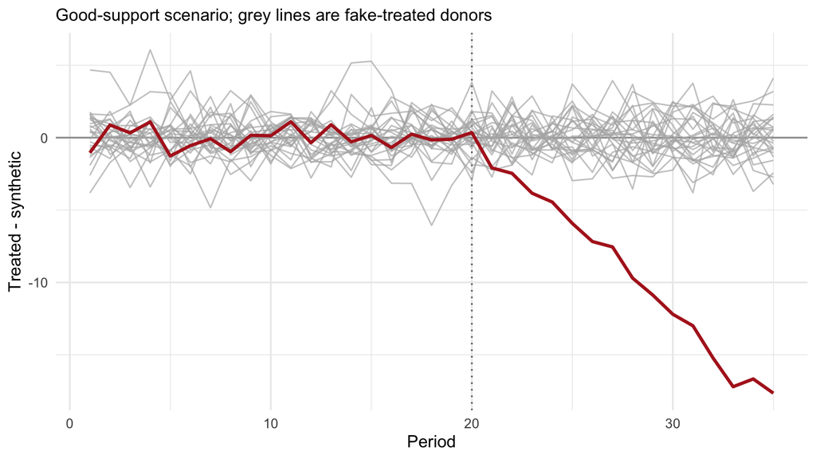

Figure 5: Placebo gaps (grey) against the treated unit (red). The treated trajectory leaves the placebo distribution after treatment.

```r
ggplot() +
  geom_hline(yintercept = 0, colour = "grey60") +
  geom_vline(xintercept = T0, linetype = "dotted", colour = "grey40") +
  geom_line(data = pl_keep, aes(time, gap, group = unit),
            colour = PAL[["donor"]], alpha = 0.7, linewidth = 0.5) +
  geom_line(data = data.frame(time = 1:TT, gap = fit_good$gap),
            aes(time, gap), colour = PAL[["treated"]], linewidth = 1.1) +
  labs(x = "Period", y = "Treated - synthetic",
       subtitle = "Good-support scenario; grey lines are fake-treated donors")
```

**Python**

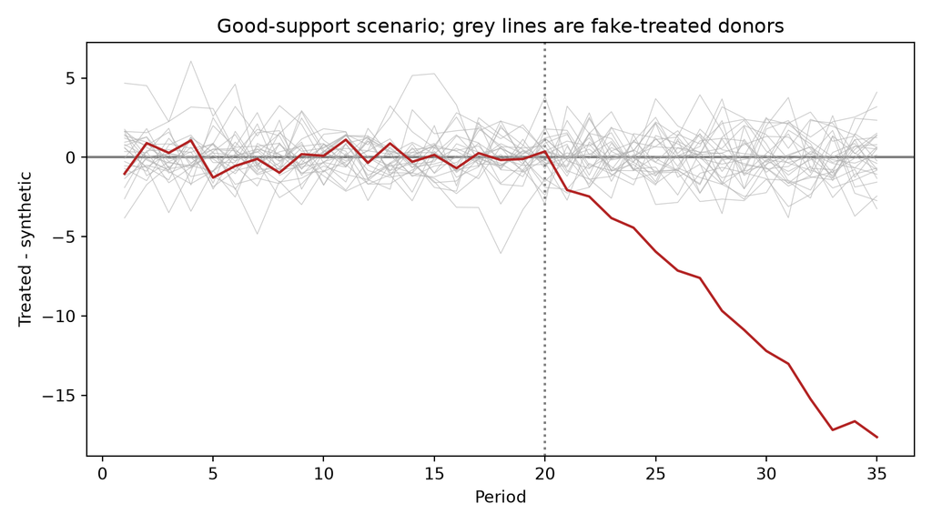

Figure 6

```python
fig, ax = plt.subplots(figsize=(8, 4.5))
ax.axhline(0, color="grey")
ax.axvline(T0, color="grey", linestyle=":")
for p in pl_keep:
    ax.plot(range(1, TT + 1), p["gap"], color="0.7", alpha=0.7, lw=0.5)
ax.plot(range(1, TT + 1), fit_good["gap"], color="#B22222", lw=1.5)
ax.set_xlabel("Period")
ax.set_ylabel("Treated - synthetic")
ax.set_title("Good-support scenario; grey lines are fake-treated donors")
plt.tight_layout()
plt.show()
```

**Stata**

```stata
* Treated unit's own gap (fit here so the block is self-contained).
import delimited "synthetic-control_files/data/sim_good.csv", clear
tsset id time
local pre ""
forvalues t = 1/20 {
    local pre "`pre' y(`t')"
}
quietly synth y `pre', trunit(1) trperiod(21) mspeperiod(1(1)20) ///
    resultsperiod(1(1)35) keep("synthetic-control_files/stata/_tr", replace)
use "synthetic-control_files/stata/_tr", clear
gen treated_gap = _Y_treated - _Y_synthetic
rename _time time
keep time treated_gap
tempfile trg
save `trg'
* Placebo spaghetti (from placebo block), screened, with the treated line on top.
use "synthetic-control_files/stata/_placebo", clear
keep if rmspe <= 5 * 0.67
sort unit time                     // connect(ascending) draws one line per unit
merge m:1 time using `trg', nogenerate
twoway (line gap time, connect(ascending) lcolor(gs11) lwidth(vthin)) ///
       (line treated_gap time, lcolor("178 34 34") lwidth(medthick)), ///
       yline(0) xline(20, lpattern(dot)) legend(off) ///
       xtitle("Period") ytitle("Treated - synthetic")
quietly graph export "sc_figs/fig-placebo-stata.svg", replace width(1600)
```

[output not shown]

[figure not shown]

The permutation p-value follows directly. We use the mean post-treatment gap as the statistic and compare in the direction of the hypothesized negative effect.

**R**

```r
stat <- function(g, T0, TT) mean(g[(T0 + 1):TT])

placebo_stats <- pl_keep |>
  group_by(unit) |>
  summarise(S = stat(gap, T0, TT), .groups = "drop")

S_treated <- stat(fit_good$gap, T0, TT)
p_val <- (1 + sum(placebo_stats$S <= S_treated)) / (1 + nrow(placebo_stats))

cat("Treated statistic:", round(S_treated, 2), "\n")
```

```
Treated statistic: -9.73
```

```r
cat("Placebo units    :", nrow(placebo_stats), "\n")
```

```
Placebo units    : 25
```

```r
cat("One-sided p-value:", round(p_val, 4), "\n")
```

```
One-sided p-value: 0.0385
```

**Python**

```python
def stat(gap):
    return gap[T0:].mean()

placebo_S = [stat(p["gap"]) for p in pl_keep]
S_treated = stat(fit_good["gap"])
p_val = (1 + sum(s <= S_treated for s in placebo_S)) / (1 + len(placebo_S))

print(f"Treated statistic: {round(S_treated, 2)}")
```

```
Treated statistic: -9.73
```

```python
print(f"Placebo units    : {len(placebo_S)}")
```

```
Placebo units    : 25
```

```python
print(f"One-sided p-value: {round(p_val, 4)}")
```

```
One-sided p-value: 0.0385
```

**Stata**

```stata
* Treated statistic (mean post-period gap) from the good-support fit.
import delimited "synthetic-control_files/data/sim_good.csv", clear
tsset id time
local pre ""
forvalues t = 1/20 {
    local pre "`pre' y(`t')"
}
quietly synth y `pre', trunit(1) trperiod(21) mspeperiod(1(1)20) ///
    resultsperiod(1(1)35) keep("synthetic-control_files/stata/_tr", replace)
use "synthetic-control_files/stata/_tr", clear
gen gap = _Y_treated - _Y_synthetic
quietly summarize gap if _time > 20
scalar S_tr = r(mean)
* Placebo statistics, screened, one per unit.
use "synthetic-control_files/stata/_placebo", clear
keep if rmspe <= 5 * 0.67
collapse (mean) S = gap if time > 20, by(unit)
count if S <= S_tr
scalar p = (1 + r(N)) / (1 + _N)
display "Treated statistic: " %5.2f S_tr
display "Placebo units    : " _N
display "One-sided p-value: " %6.4f p
```

```
(encoding automatically selected: UTF-8)
(4 vars, 910 obs)


Panel variable: id (strongly balanced)
 Time variable: time, 1 to 35
         Delta: 1 unit









(0 observations deleted)


  0


Treated statistic: -9.73

Placebo units    : 25

One-sided p-value: 0.0385

counter | pri_inf  | dual_inf  | pri_obj   | dual_obj  | sigfig | alpha  | nu
----------------------------------------------------------------------------------
      0 | 6.73e+01 | 1.32e-08 | -3.96e+02 | -6.46e+02 |  0.201 | 0.0000 | 1.00e+02
      1 | 3.36e-01 | 6.62e-11 | -3.96e+02 | -8.51e+02 |  0.000 | 0.9950 | 2.07e-05
      2 | 1.68e-03 | 3.31e-13 | -3.96e+02 | -4.05e+02 |  1.633 | 0.9950 | 2.07e-06
      3 | 5.64e-05 | 1.11e-14 | -3.96e+02 | -3.96e+02 |  3.106 | 0.9664 | 1.74e-06
      4 | 6.30e-06 | 1.24e-15 | -3.96e+02 | -3.96e+02 |  4.026 | 0.8884 | 6.53e-07
      5 | 1.83e-06 | 3.61e-16 | -3.96e+02 | -3.96e+02 |  4.560 | 0.7090 | 5.53e-07
      6 | 3.44e-07 | 6.78e-17 | -3.96e+02 | -3.96e+02 |  5.235 | 0.8123 | 6.59e-08
      7 | 7.80e-09 | 1.57e-18 | -3.96e+02 | -3.96e+02 |  6.565 | 0.9773 | 1.97e-10
      8 | 1.62e-10 | 5.22e-20 | -3.96e+02 | -3.96e+02 |  8.034 | 0.9792 | 7.76e-12
      9 | 9.57e-13 | 6.42e-20 | -3.96e+02 | -3.96e+02 | 10.040 | 0.9941 | 2.11e-14
     10 | 4.90e-15 | 6.69e-20 | -3.96e+02 | -3.96e+02 | 12.338 | 0.9950 | 1.50e-16
----------------------------------------------------------------------------------
optimization converged
```